# PART A: Box Plots

```python
from matplotlib import pyplot as plt
%matplotlib inline

plt.rcParams["figure.dpi"] = 80

import pandas as pd
import numpy as np
import scipy.stats as stats
import statsmodels.api as sm
import statsmodels.stats.api as sms
import statsmodels.formula.api as smf
import statsmodels.stats.multicomp as smm
import statsmodels
```

```python
#讀取資料集
df = open('Coronavirus_1.csv')
df1 = pd.read_csv(df)
df1 = df1.rename(columns = {'BCG %': 'BCG'})
print('Head of dataset:')
display(df1.head())
print("Tail of dataset:")
display(df1.tail())
```

```
Head of dataset:
```

|  | Unnamed: 0 | region | cases | not cases | health_exp_per_capita | per_capita_exp_PPP_2016 | Physicians_per_1000_2009to18 | Nurse_midwife_per_1000_2009to18 | Specialist_surgical_workforce | HDI | Life_Expectancy | Expected_year_of_schooling | Mean_year_of_schooling | GNI_per_capita | Latitude | Density | Med_age | Urban_pop_proportion | BCG |
| --- | --- | --- | --- | --- | --- | --- | --- | --- | --- | --- | --- | --- | --- | --- | --- | --- | --- | --- | --- |
| 0 | 0 | Afghanistan | 6402 | 38736509 | 57.2 | 162.8 | 0.3 | 0.3 | 0.0 | 0.498 | 64.0 | 10.4 | 3.8 | 1824.0 | 33.0000 | 60.0 | 18.0 | 0.25 | 78.0 |
| 1 | 1 | Albania | 933 | 2877487 | 271.5 | 759.7 | 1.2 | 3.6 | 11.6 | 0.785 | 78.5 | 14.8 | 10.0 | 11886.0 | 41.1533 | 105.0 | 36.0 | 0.63 | 99.0 |
| 2 | 2 | Algeria | 6821 | 43678797 | 260.4 | 998.2 | 1.8 | 2.2 | 12.1 | 0.754 | 76.3 | 14.4 | 8.0 | 13802.0 | 28.0339 | 18.0 | 29.0 | 0.73 | 99.0 |
| 3 | 3 | Andorra | 761 | 76479 | 3834.7 | 4978.7 | 3.3 | 4.0 | 83.1 | 0.858 | 81.7 | 13.5 | 10.2 | 47574.0 | 42.5063 | 164.0 | NaN | 0.88 | NaN |
| 4 | 4 | Angola | 48 | 32644735 | 95.2 | 185.8 | 0.2 | 1.3 | NaN | 0.581 | 61.8 | 11.8 | 5.1 | 5790.0 | -11.2027 | 26.0 | 17.0 | 0.67 | 86.0 |

```
Tail of dataset:
```

|  | Unnamed: 0 | region | cases | not cases | health_exp_per_capita | per_capita_exp_PPP_2016 | Physicians_per_1000_2009to18 | Nurse_midwife_per_1000_2009to18 | Specialist_surgical_workforce | HDI | Life_Expectancy | Expected_year_of_schooling | Mean_year_of_schooling | GNI_per_capita | Latitude | Density | Med_age | Urban_pop_proportion | BCG |
| --- | --- | --- | --- | --- | --- | --- | --- | --- | --- | --- | --- | --- | --- | --- | --- | --- | --- | --- | --- |
| 190 | 190 | Sao Tome and Principe | 235 | 218073 | 105.1 | 196.9 | 0.3 | 2.3 | NaN | 0.589 | 66.8 | 12.5 | 6.3 | 2941.0 | 0.186360 | 228.0 | 19.0 | 0.74 | 96.0 |
| 191 | 191 | Yemen, Rep. | 122 | 29687092 | 72.0 | 144.5 | 0.3 | 0.7 | 0.8 | 0.452 | 65.2 | 9.0 | 3.0 | 1239.0 | 15.552727 | 56.0 | 20.0 | 0.38 | 64.0 |
| 192 | 192 | Comoros | 11 | 865685 | 59.0 | 115.8 | 0.2 | 0.9 | NaN | 0.503 | 63.9 | 11.2 | 4.8 | 1399.0 | -11.645500 | 467.0 | 20.0 | 0.29 | 94.0 |
| 193 | 193 | Tajikistan | 1322 | 9491020 | 55.7 | 208.5 | 1.7 | 5.2 | 41.7 | 0.650 | 71.2 | 11.2 | 10.4 | 3317.0 | 38.861034 | 68.0 | 22.0 | 0.27 | 99.0 |
| 194 | 194 | Lesotho | 1 | 2138798 | 85.5 | 242.7 | 0.1 | 0.7 | 0.6 | 0.520 | 54.6 | 10.6 | 6.3 | 3255.0 | -29.609988 | 71.0 | 24.0 | 0.31 | 98.0 |

將以下每個變數繪製成盒狀圖，藉此觀察與比較不同分位間確診人數的分布情況。

1. 人均衛生支出（USD） Current health expenditure per capita (current US$)
2. 人均衛生支出（使用平均購買力校正） Current health expenditure per capita, PPP (current international $)
3. 醫師密度 Physicians (per 1,000 people)
4. 護士密度 Nurses and midwives (per 1,000 people)
5. 專科手術人員密度 Specialist surgical workforce (per 100,000 population)
6. HDI
7. BCG

## Draw Box Plot

```python
def drawBoxPlot(data , name) :
    data = data.dropna()
    df = pd.DataFrame(data)
    plt.title(name)
    _, bp = df.boxplot(vert=False , return_type='both')
    print("Quantile :")
    print(df.quantile([0.25 ,0.5 ,0.75]))
```

```python
def findOutliers(data , name) :
    Q1 = data.quantile(0.25)
    Q3 = data.quantile(0.75)
    IQR = Q3 - Q1
    right_whisker = Q3 + 1.5*IQR
    left_whisker = Q1 - 1.5*IQR
    right_region = []
    left_region = []
    right_outlier = []
    left_outlier = []
    for i in range(len(data)) :
        if(data[i] > right_whisker) :
            right_region.append(df1["region"][i])
            right_outlier.append(data[i])
        elif(data[i] < left_whisker) :
            left_region.append(df1["region"][i])
            left_outlier.append(data[i])
    r = {"region":right_region , name:right_outlier}
    l = {"region":left_region , name:left_outlier}
    df_r = pd.DataFrame(r)
    df_l = pd.DataFrame(l)
    print("Right outliers :")
    if(len(df_r.index) != 0) :
        print(df_r)
    print("The number of right outliers :" , len(df_r.index))
    print("Left outliers :")
    if(len(df_l.index) != 0) :
        print(df_l)
    print("The number of left outliers :" , len(df_l.index))
```

### 1. Current health expenditure per capita (current US$)

```
Quantile :
      health_exp_per_capita
0.25                 79.450
0.50                327.500
0.75               1135.325
```

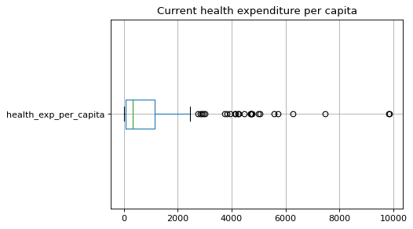

```python
drawBoxPlot(df1['health_exp_per_capita'] ,'Current health expenditure per capita')
```

```python
findOutliers(df1['health_exp_per_capita'] ,'Current health expenditure per capita')
```

```
Right outliers :
            region  Current health expenditure per capita
0          Andorra                                 3834.7
1        Australia                                 5002.4
2          Austria                                 4688.3
3          Belgium                                 4149.4
4           Canada                                 4458.2
5        Hong Kong                                 2898.3
6          Denmark                                 5565.6
7          Finland                                 4117.3
8           France                                 4263.4
9          Germany                                 4714.3
10         Iceland                                 5063.6
11         Ireland                                 4758.6
12          Israel                                 2837.1
13           Italy                                 2738.7
14           Japan                                 4233.0
15      Luxembourg                                 6271.4
16          Monaco                                 2939.8
17     Netherlands                                 4742.0
18     New Zealand                                 3745.2
19          Norway                                 7477.9
20      San Marino                                 3012.8
21          Sweden                                 5710.6
22     Switzerland                                 9836.0
23  United Kingdom                                 3958.0
24   United States                                 9869.7
The number of right outliers : 25
Left outliers :
The number of left outliers : 0
```

人均衛生支出的中位數約是327美金，分佈是positive skewed的。約75%的國家人均衛生支出都在1135美金之下，但花費最高前25％的國家分佈則有非常大的差異，最多到達9869美金約是1135美金的9倍。

### 2. Current health expenditure per capita, PPP (current international $)

```
Quantile :
      per_capita_exp_PPP_2016
0.25                  224.875
0.50                  818.050
0.75                 1966.975
Right outliers :
           region  Current health expenditure per capita, PPP
0         Andorra                                      4978.7
1         Austria                                      5295.2
2         Belgium                                      4667.9
3          Canada                                      4718.3
4         Denmark                                      5093.0
5          France                                      4782.3
6         Germany                                      5463.3
7         Ireland                                      5299.7
8           Japan                                      4592.4
9      Luxembourg                                      6374.2
10    Netherlands                                      5251.2
11         Norway                                      6203.5
12         Sweden                                      5386.7
13    Switzerland                                      7867.4
14  United States                                      9869.7
The number of right outliers : 15
Left outliers :
The number of left outliers : 0
```

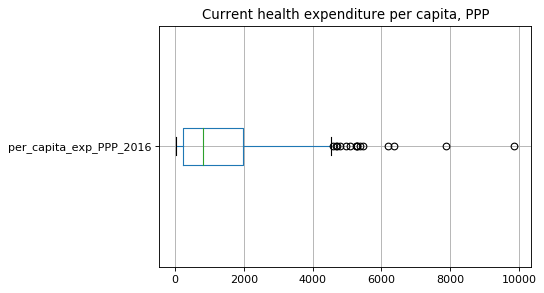

```python
drawBoxPlot(df1['per_capita_exp_PPP_2016'] ,'Current health expenditure per capita, PPP')
findOutliers(df1['per_capita_exp_PPP_2016'] ,'Current health expenditure per capita, PPP')
```

人均衛生支出（校正過）的中位數約是818美金，分佈是positive skewed的，且$Q_3$(1967)將近是$Q_1$(225)的9倍。即使用平均購買力校正後，各國的人均衛生支出還是差異非常大。且這筆資料的離群值多為歐美國家。

### 3. Physicians (per 1,000 people)

```
Quantile :
      Physicians_per_1000_2009to18
0.25                           0.3
0.50                           1.4
0.75                           2.9
Right outliers :
  region  Physicians (per 1,000 people)
0   Cuba                            8.2
The number of right outliers : 1
Left outliers :
The number of left outliers : 0
```

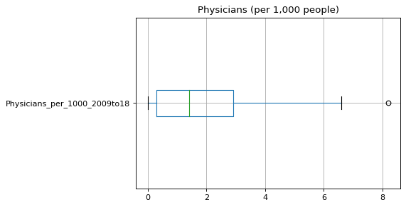

```python
drawBoxPlot(df1['Physicians_per_1000_2009to18'] ,'Physicians (per 1,000 people)')
findOutliers(df1['Physicians_per_1000_2009to18'] ,'Physicians (per 1,000 people)')
```

醫生密度的中位數約為每千人中對應到1.4人，且分佈是positive skewed的。所有古巴公民都有權在該國所有醫療機構接受免費醫療，且該國投入約10%GDP在醫療系統中，所以才有這冠絕全世界的醫生密度(平均每千人對應到8.2位醫生)

### 4. Nurses and midwives (per 1,000 people)

```
Quantile :
      Nurse_midwife_per_1000_2009to18
0.25                              1.0
0.50                              2.6
0.75                              6.4
Right outliers :
        region  Nurses and midwives (per 1,000 people)
0      Finland                                    14.7
1      Iceland                                    15.7
2       Monaco                                    20.3
3       Norway                                    18.1
4  Switzerland                                    17.3
The number of right outliers : 5
Left outliers :
The number of left outliers : 0
```

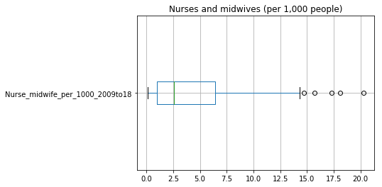

```python
drawBoxPlot(df1['Nurse_midwife_per_1000_2009to18'] ,'Nurses and midwives (per 1,000 people)')
findOutliers(df1['Nurse_midwife_per_1000_2009to18'] ,'Nurses and midwives (per 1,000 people)')
```

### 5. Specialist surgical workforce (per 100,000 population)

```
Quantile :
      Specialist_surgical_workforce
0.25                          2.975
0.50                         24.050
0.75                         65.425
Right outliers :
   region  Specialist surgical workforce (per 100,000 population)
0  Greece                                              163.5
1  Monaco                                              195.6
The number of right outliers : 2
Left outliers :
The number of left outliers : 0
```

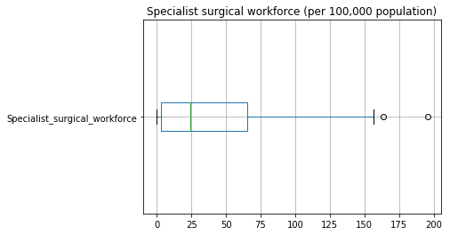

```python
drawBoxPlot(df1['Specialist_surgical_workforce'] ,'Specialist surgical workforce (per 100,000 population)')
findOutliers(df1['Specialist_surgical_workforce'] ,'Specialist surgical workforce (per 100,000 population)')
```

## 以上這5個指標都有很明顯的positive skewness、右尾很長，代表醫療資源在國與國之間分佈極不均勻。

### 6. HDI

```
Quantile :
        HDI
0.25  0.589
0.50  0.747
0.75  0.838
```

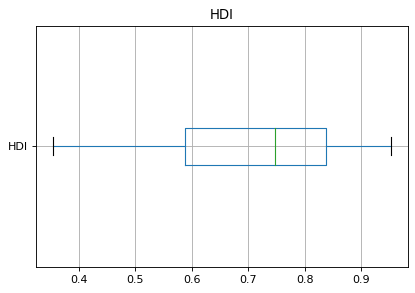

```python
drawBoxPlot(df1['HDI'] ,'HDI')
#findOutliers(df1['HDI'] ,'HDI')
```

HDI依照大小分為4組：極高、高、中、低，在0.8以上就被歸類於「極高」，0.7和0.8之間則是「高」，我們的樣本國家中超過5成HDI都在「高」以上的範疇。$Q_1$以下的國家差異分布較大

### 7. BCG

```
Quantile :
       BCG
0.25  88.0
0.50  95.0
0.75  98.0
Right outliers :
The number of right outliers : 0
Left outliers :
               region   BCG
0                Chad  59.0
1   Equatorial Guinea  63.0
2              Guinea  72.0
3          Madagascar  70.0
4             Nigeria  53.0
5    Papua New Guinea  69.0
6             Somalia  37.0
7        South Africa  70.0
8              Sweden  26.0
9         South Sudan  52.0
10        Yemen, Rep.  64.0
The number of left outliers : 11
```

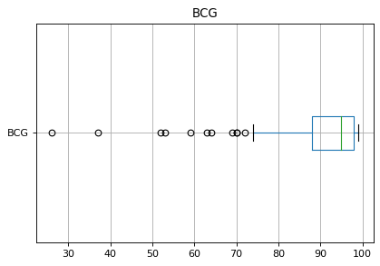

```python
drawBoxPlot(df1['BCG'] ,'BCG')
findOutliers(df1['BCG'] ,'BCG')
```

施打率的中位數約在95％，且大約7成的國家卡介苗施打率都在90％以上，而施打率的離群值（低）多來自第三世界的國家，但滿令人意外的是瑞典的施打率僅26%。

# PART B: Multiple Regression

```python
#讀取資料集
df = pd.read_csv('Coronavirus_1.csv')

# 簡單看一下資料集的樣子
# 如果這是你第一次使用這個資料集，使用Excel開啟資料集，
#並確認程式讀到的跟你在Excel中看到的一樣

print('Head of dataset:')
display(df.head())
print("Tail of dataset:")
display(df.tail())
```

```
Head of dataset:
```

|  | Unnamed: 0 | region | cases | not cases | health_exp_per_capita | per_capita_exp_PPP_2016 | Physicians_per_1000_2009to18 | Nurse_midwife_per_1000_2009to18 | Specialist_surgical_workforce | HDI | Life_Expectancy | Expected_year_of_schooling | Mean_year_of_schooling | GNI_per_capita | Latitude | Density | Med_age | Urban_pop_proportion | BCG |
| --- | --- | --- | --- | --- | --- | --- | --- | --- | --- | --- | --- | --- | --- | --- | --- | --- | --- | --- | --- |
| 0 | 0 | Afghanistan | 6402 | 38736509 | 57.2 | 162.8 | 0.3 | 0.3 | 0.0 | 0.498 | 64.0 | 10.4 | 3.8 | 1824.0 | 33.0000 | 60.0 | 18.0 | 0.25 | 78.0 |
| 1 | 1 | Albania | 933 | 2877487 | 271.5 | 759.7 | 1.2 | 3.6 | 11.6 | 0.785 | 78.5 | 14.8 | 10.0 | 11886.0 | 41.1533 | 105.0 | 36.0 | 0.63 | 99.0 |
| 2 | 2 | Algeria | 6821 | 43678797 | 260.4 | 998.2 | 1.8 | 2.2 | 12.1 | 0.754 | 76.3 | 14.4 | 8.0 | 13802.0 | 28.0339 | 18.0 | 29.0 | 0.73 | 99.0 |
| 3 | 3 | Andorra | 761 | 76479 | 3834.7 | 4978.7 | 3.3 | 4.0 | 83.1 | 0.858 | 81.7 | 13.5 | 10.2 | 47574.0 | 42.5063 | 164.0 | NaN | 0.88 | NaN |
| 4 | 4 | Angola | 48 | 32644735 | 95.2 | 185.8 | 0.2 | 1.3 | NaN | 0.581 | 61.8 | 11.8 | 5.1 | 5790.0 | -11.2027 | 26.0 | 17.0 | 0.67 | 86.0 |

```
Tail of dataset:
```

|  | Unnamed: 0 | region | cases | not cases | health_exp_per_capita | per_capita_exp_PPP_2016 | Physicians_per_1000_2009to18 | Nurse_midwife_per_1000_2009to18 | Specialist_surgical_workforce | HDI | Life_Expectancy | Expected_year_of_schooling | Mean_year_of_schooling | GNI_per_capita | Latitude | Density | Med_age | Urban_pop_proportion | BCG |
| --- | --- | --- | --- | --- | --- | --- | --- | --- | --- | --- | --- | --- | --- | --- | --- | --- | --- | --- | --- |
| 190 | 190 | Sao Tome and Principe | 235 | 218073 | 105.1 | 196.9 | 0.3 | 2.3 | NaN | 0.589 | 66.8 | 12.5 | 6.3 | 2941.0 | 0.186360 | 228.0 | 19.0 | 0.74 | 96.0 |
| 191 | 191 | Yemen, Rep. | 122 | 29687092 | 72.0 | 144.5 | 0.3 | 0.7 | 0.8 | 0.452 | 65.2 | 9.0 | 3.0 | 1239.0 | 15.552727 | 56.0 | 20.0 | 0.38 | 64.0 |
| 192 | 192 | Comoros | 11 | 865685 | 59.0 | 115.8 | 0.2 | 0.9 | NaN | 0.503 | 63.9 | 11.2 | 4.8 | 1399.0 | -11.645500 | 467.0 | 20.0 | 0.29 | 94.0 |
| 193 | 193 | Tajikistan | 1322 | 9491020 | 55.7 | 208.5 | 1.7 | 5.2 | 41.7 | 0.650 | 71.2 | 11.2 | 10.4 | 3317.0 | 38.861034 | 68.0 | 22.0 | 0.27 | 99.0 |
| 194 | 194 | Lesotho | 1 | 2138798 | 85.5 | 242.7 | 0.1 | 0.7 | 0.6 | 0.520 | 54.6 | 10.6 | 6.3 | 3255.0 | -29.609988 | 71.0 | 24.0 | 0.31 | 98.0 |

```python
# 把有缺任何一個column data的row刪掉
df_dropAll = df.dropna(axis = 0, how = 'any')
print('Head of dataset:')
display(df_dropAll.head())
print("Tail of dataset:")
display(df_dropAll.tail())
```

```
Head of dataset:
```

|  | Unnamed: 0 | region | cases | not cases | health_exp_per_capita | per_capita_exp_PPP_2016 | Physicians_per_1000_2009to18 | Nurse_midwife_per_1000_2009to18 | Specialist_surgical_workforce | HDI | Life_Expectancy | Expected_year_of_schooling | Mean_year_of_schooling | GNI_per_capita | Latitude | Density | Med_age | Urban_pop_proportion | BCG |
| --- | --- | --- | --- | --- | --- | --- | --- | --- | --- | --- | --- | --- | --- | --- | --- | --- | --- | --- | --- |
| 0 | 0 | Afghanistan | 6402 | 38736509 | 57.2 | 162.8 | 0.3 | 0.3 | 0.0 | 0.498 | 64.0 | 10.4 | 3.8 | 1824.0 | 33.0000 | 60.0 | 18.0 | 0.25 | 78.0 |
| 1 | 1 | Albania | 933 | 2877487 | 271.5 | 759.7 | 1.2 | 3.6 | 11.6 | 0.785 | 78.5 | 14.8 | 10.0 | 11886.0 | 41.1533 | 105.0 | 36.0 | 0.63 | 99.0 |
| 2 | 2 | Algeria | 6821 | 43678797 | 260.4 | 998.2 | 1.8 | 2.2 | 12.1 | 0.754 | 76.3 | 14.4 | 8.0 | 13802.0 | 28.0339 | 18.0 | 29.0 | 0.73 | 99.0 |
| 6 | 6 | Argentina | 7805 | 45103424 | 955.2 | 1531.0 | 4.0 | 2.6 | 50.1 | 0.825 | 76.7 | 17.4 | 9.9 | 18461.0 | -38.4161 | 17.0 | 32.0 | 0.93 | 93.0 |
| 7 | 7 | Armenia | 4283 | 2957854 | 358.8 | 876.9 | 2.9 | 5.6 | 86.7 | 0.755 | 74.8 | 13.0 | 11.7 | 9144.0 | 40.0691 | 104.0 | 35.0 | 0.63 | 99.0 |

```
Tail of dataset:
```

|  | Unnamed: 0 | region | cases | not cases | health_exp_per_capita | per_capita_exp_PPP_2016 | Physicians_per_1000_2009to18 | Nurse_midwife_per_1000_2009to18 | Specialist_surgical_workforce | HDI | Life_Expectancy | Expected_year_of_schooling | Mean_year_of_schooling | GNI_per_capita | Latitude | Density | Med_age | Urban_pop_proportion | BCG |
| --- | --- | --- | --- | --- | --- | --- | --- | --- | --- | --- | --- | --- | --- | --- | --- | --- | --- | --- | --- |
| 187 | 187 | Sierra Leone | 462 | 7942417 | 86.3 | 244.0 | 0.0 | 1.0 | 0.1 | 0.419 | 52.2 | 9.8 | 3.5 | 1240.0 | 8.460555 | 111.0 | 19.0 | 0.43 | 90.0 |
| 188 | 188 | Malawi | 65 | 19024361 | 29.6 | 115.2 | 0.0 | 0.3 | 0.4 | 0.477 | 63.7 | 10.8 | 4.5 | 1064.0 | -13.254308 | 203.0 | 18.0 | 0.18 | 92.0 |
| 191 | 191 | Yemen, Rep. | 122 | 29687092 | 72.0 | 144.5 | 0.3 | 0.7 | 0.8 | 0.452 | 65.2 | 9.0 | 3.0 | 1239.0 | 15.552727 | 56.0 | 20.0 | 0.38 | 64.0 |
| 193 | 193 | Tajikistan | 1322 | 9491020 | 55.7 | 208.5 | 1.7 | 5.2 | 41.7 | 0.650 | 71.2 | 11.2 | 10.4 | 3317.0 | 38.861034 | 68.0 | 22.0 | 0.27 | 99.0 |
| 194 | 194 | Lesotho | 1 | 2138798 | 85.5 | 242.7 | 0.1 | 0.7 | 0.6 | 0.520 | 54.6 | 10.6 | 6.3 | 3255.0 | -29.609988 | 71.0 | 24.0 | 0.31 | 98.0 |

```python
#print(df_dropAll['GNI_per_capita'])
max(df_dropAll['GNI_per_capita'])
```

```
116818.0
```

```python
counter = 0
for i in df_dropAll['region']:
    print(i)
    counter = counter+1
    if counter%5 == 0:
        print("------")
print(counter)
```

```
Afghanistan
Albania
Algeria
Argentina
Armenia
------
Azerbaijan
Bangladesh
Belarus
Benin
Bhutan
------
Bolivia
Bosnia and Herzegovina
Brazil
Bulgaria
Burkina Faso
------
Cabo Verde
Cambodia
Cameroon
Central African Republic
Chad
------
Chile
China
Colombia
Congo (Brazzaville)
Congo (Kinshasa)
------
Costa Rica
Cote d'Ivoire
Croatia
Cuba
Djibouti
------
Ecuador
Egypt
El Salvador
Estonia
```

[output cut: 76 more lines]

```
Mozambique
Timor-Leste
Belize
------
Mali
Myanmar
Botswana
Burundi
Sierra Leone
------
Malawi
Yemen, Rep.
Tajikistan
Lesotho
109
```

### Scatter Plot

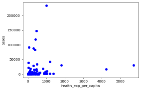

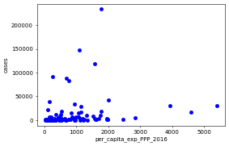

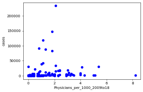

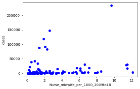

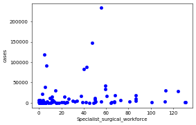

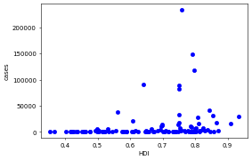

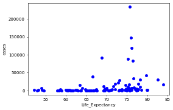

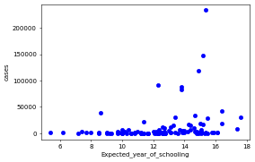

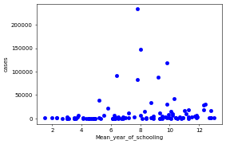

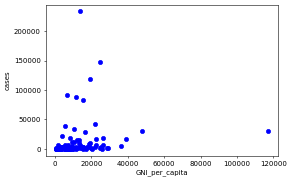

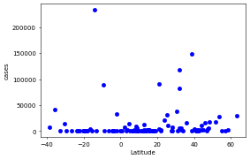

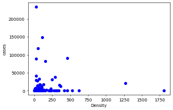

[3 more figures not shown]

```python
y = df_dropAll['cases'].values
xnames = ['health_exp_per_capita', 'per_capita_exp_PPP_2016', 'Physicians_per_1000_2009to18', 'Nurse_midwife_per_1000_2009to18', 'Specialist_surgical_workforce', 'HDI', 'Life_Expectancy', 'Expected_year_of_schooling', 'Mean_year_of_schooling', 'GNI_per_capita', 'Latitude', 'Density', 'Med_age', 'Urban_pop_proportion', 'BCG']
for aname in xnames:
    x = df_dropAll[aname].values

    _ = plt.plot(x, y, 'o', color = 'b')
    #plt.xlim(0,120000)
    plt.xlabel(aname)
    plt.ylabel('cases')
    plt.show()
```

## 針對前6個獨立變數的回歸

```python
result_dropAll1 = smf.ols(
    'cases ~ health_exp_per_capita + per_capita_exp_PPP_2016 + Physicians_per_1000_2009to18 + Nurse_midwife_per_1000_2009to18 + Specialist_surgical_workforce + HDI',
    data=df_dropAll).fit()
# Inspect the results
print(result_dropAll1.summary())
```

```
                            OLS Regression Results
==============================================================================
Dep. Variable:                  cases   R-squared:                       0.088
Model:                            OLS   Adj. R-squared:                  0.034
Method:                 Least Squares   F-statistic:                     1.633
Date:                Mon, 01 Jun 2020   Prob (F-statistic):              0.146
Time:                        23:15:11   Log-Likelihood:                -1279.1
No. Observations:                 109   AIC:                             2572.
Df Residuals:                     102   BIC:                             2591.
Df Model:                           6
Covariance Type:            nonrobust
===================================================================================================
                                      coef    std err          t      P>|t|      [0.025      0.975]
---------------------------------------------------------------------------------------------------
Intercept                       -1.804e+04   2.13e+04     -0.848      0.398   -6.02e+04    2.41e+04
health_exp_per_capita              -5.8468     10.624     -0.550      0.583     -26.919      15.225
per_capita_exp_PPP_2016             8.5828     10.654      0.806      0.422     -12.550      29.715
Physicians_per_1000_2009to18    -7221.0014   4401.955     -1.640      0.104    -1.6e+04    1510.256
Nurse_midwife_per_1000_2009to18   883.5074   1792.045      0.493      0.623   -2671.005    4438.020
Specialist_surgical_workforce     176.0319    199.544      0.882      0.380    -219.762     571.826
HDI                              4.185e+04   3.87e+04      1.081      0.282    -3.5e+04    1.19e+05
==============================================================================
Omnibus:                      132.922   Durbin-Watson:                   2.006
Prob(Omnibus):                  0.000   Jarque-Bera (JB):             2649.717
Skew:                           4.366   Prob(JB):                         0.00
Kurtosis:                      25.520   Cond. No.                     2.10e+04
==============================================================================

Warnings:
[1] Standard Errors assume that the covariance matrix of the errors is correctly specified.
[2] The condition number is large, 2.1e+04. This might indicate that there are
strong multicollinearity or other numerical problems.
```

```python
df_dropAll1 = df_dropAll[['cases', 'region', 'health_exp_per_capita', 'per_capita_exp_PPP_2016', 'Physicians_per_1000_2009to18', 'Nurse_midwife_per_1000_2009to18', 'Specialist_surgical_workforce', 'HDI']]
corr11 = df_dropAll1.corr()
```

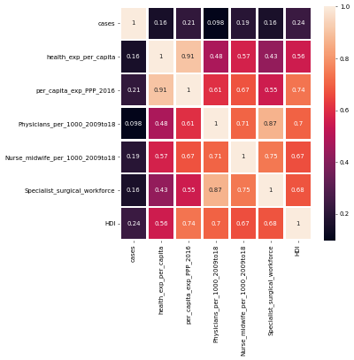

```python
plt.figure(figsize=(7, 7))
_ = sns.heatmap(corr11, annot=True, linewidths=2)
```

### 1.) 全部直接做一次multiple regression

```python
result_dropAll = smf.ols(
    'cases ~ health_exp_per_capita + per_capita_exp_PPP_2016 + Physicians_per_1000_2009to18 + Nurse_midwife_per_1000_2009to18 + Specialist_surgical_workforce + HDI + Life_Expectancy + GNI_per_capita + Expected_year_of_schooling + Mean_year_of_schooling +  Latitude + Density + Med_age + Urban_pop_proportion + BCG',
    data=df_dropAll).fit()
# Inspect the results
print(result_dropAll.summary())
```

```
                            OLS Regression Results
==============================================================================
Dep. Variable:                  cases   R-squared:                       0.232
Model:                            OLS   Adj. R-squared:                  0.108
Method:                 Least Squares   F-statistic:                     1.871
Date:                Thu, 04 Jun 2020   Prob (F-statistic):             0.0362
Time:                        22:10:49   Log-Likelihood:                -1269.7
No. Observations:                 109   AIC:                             2571.
Df Residuals:                      93   BIC:                             2614.
Df Model:                          15
Covariance Type:            nonrobust
===================================================================================================
                                      coef    std err          t      P>|t|      [0.025      0.975]
---------------------------------------------------------------------------------------------------
Intercept                       -4.593e+04   4.53e+04     -1.014      0.313   -1.36e+05     4.4e+04
health_exp_per_capita             -14.7183     12.907     -1.140      0.257     -40.348      10.911
per_capita_exp_PPP_2016            10.9839     15.353      0.715      0.476     -19.503      41.471
Physicians_per_1000_2009to18    -1.017e+04   4830.514     -2.105      0.038   -1.98e+04    -578.008
Nurse_midwife_per_1000_2009to18  4070.6563   1968.599      2.068      0.041     161.409    7979.904
Specialist_surgical_workforce     337.6603    211.961      1.593      0.115     -83.252     758.573
HDI                              1.156e+05   1.25e+05      0.926      0.357   -1.32e+05    3.64e+05
Life_Expectancy                   381.8530   1089.309      0.351      0.727   -1781.298    2545.004
GNI_per_capita                     -0.4432      0.488     -0.908      0.366      -1.413       0.526
Expected_year_of_schooling       2104.3145   3023.144      0.696      0.488   -3899.050    8107.680
Mean_year_of_schooling          -7188.3358   2884.375     -2.492      0.014   -1.29e+04   -1460.538
Latitude                         -151.8116    174.785     -0.869      0.387    -498.899     195.276
Density                             4.6644     14.165      0.329      0.743     -23.465      32.793
Med_age                          -255.9422    875.944     -0.292      0.771   -1995.393    1483.508
Urban_pop_proportion             4.013e+04   2.12e+04      1.893      0.061   -1968.152    8.22e+04
BCG                              -371.7801    346.510     -1.073      0.286   -1059.880     316.319
==============================================================================
Omnibus:                       97.158   Durbin-Watson:                   2.001
Prob(Omnibus):                  0.000   Jarque-Bera (JB):              810.718
Skew:                           3.081   Prob(JB):                    9.01e-177
Kurtosis:                      14.855   Cond. No.                     7.82e+05
==============================================================================

Warnings:
[1] Standard Errors assume that the covariance matrix of the errors is correctly specified.
[2] The condition number is large, 7.82e+05. This might indicate that there are
strong multicollinearity or other numerical problems.
```

According to the p value of t test, only the Physicians_per_1000_2009to18, Nurse_midwife_per_1000_2009to18, Q("Mean year of schooling") variable can be reject.Thus, we compute the multiple regression again with the three variables.

### 1.a) 把顯著的三個variable抓出來做一次

```python
result_dropAll = smf.ols(
    'cases ~ Physicians_per_1000_2009to18 + Nurse_midwife_per_1000_2009to18 + Mean_year_of_schooling',
    data=df_dropAll).fit()
# Inspect the results
print(result_dropAll.summary())
```

```
                            OLS Regression Results
==============================================================================
Dep. Variable:                  cases   R-squared:                       0.042
Model:                            OLS   Adj. R-squared:                  0.014
Method:                 Least Squares   F-statistic:                     1.527
Date:                Thu, 04 Jun 2020   Prob (F-statistic):              0.212
Time:                        22:10:53   Log-Likelihood:                -1281.7
No. Observations:                 109   AIC:                             2571.
Df Residuals:                     105   BIC:                             2582.
Df Model:                           3
Covariance Type:            nonrobust
===================================================================================================
                                      coef    std err          t      P>|t|      [0.025      0.975]
---------------------------------------------------------------------------------------------------
Intercept                        8638.1499   9612.575      0.899      0.371   -1.04e+04    2.77e+04
Physicians_per_1000_2009to18    -1228.4743   3328.352     -0.369      0.713   -7827.982    5371.034
Nurse_midwife_per_1000_2009to18  3004.4124   1659.958      1.810      0.073    -286.978    6295.802
Mean_year_of_schooling           -514.3088   1638.285     -0.314      0.754   -3762.725    2734.108
==============================================================================
Omnibus:                      128.460   Durbin-Watson:                   1.846
Prob(Omnibus):                  0.000   Jarque-Bera (JB):             2157.153
Skew:                           4.232   Prob(JB):                         0.00
Kurtosis:                      23.083   Cond. No.                         29.9
==============================================================================

Warnings:
[1] Standard Errors assume that the covariance matrix of the errors is correctly specified.
```

adjusted r^2 decreases.(原本顯著也變不顯著)

### Correlation

```python
df_dropAll = df_dropAll[['cases', 'region', 'health_exp_per_capita', 'per_capita_exp_PPP_2016', 'Physicians_per_1000_2009to18', 'Nurse_midwife_per_1000_2009to18', 'Specialist_surgical_workforce', 'HDI', 'Life_Expectancy', 'Expected_year_of_schooling', 'Mean_year_of_schooling', 'GNI_per_capita', 'Latitude', 'Density', 'Med_age', 'Urban_pop_proportion', 'BCG']]
corr1 = df_dropAll.corr()
```

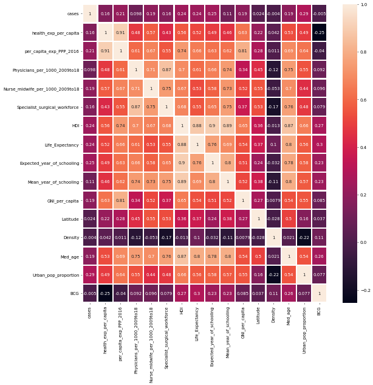

```python
#import matplotlib.pyplot as plt

plt.figure(figsize=(13, 13))
_ = sns.heatmap(corr1, annot=True, linewidths=2)
```

很多variable之間的coefficient correlation都大於0.7

#### Checking Normality Assumption

To check the normality assumption, compute the residuals, plot histogram and Q-Q plot, and conduct Shapiro test.

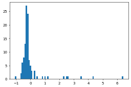

```python
_ = plt.hist(result_dropAll.resid_pearson, bins = 'auto')
```

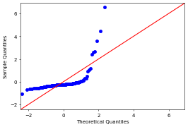

```python
fig = sm.qqplot(result_dropAll.resid_pearson, stats.norm, fit=True, line='45')
```

#### Shapiro Test

H0: The data is normally distributed.  
H1: The data is NOT normally distributed.

```python
stat, p = stats.shapiro(result_dropAll.resid_pearson)
print('Statistics=%.3f, p=%.3f' % (stat, p))
```

```
Statistics=0.467, p=0.000
```

The null hyptoehsis of Shapiro-Wilk test is that the data is normally distributed. The testing result shows that the null hyphosis can be rejected. As a result, we conclude that the normality assumption is unsatisfied.

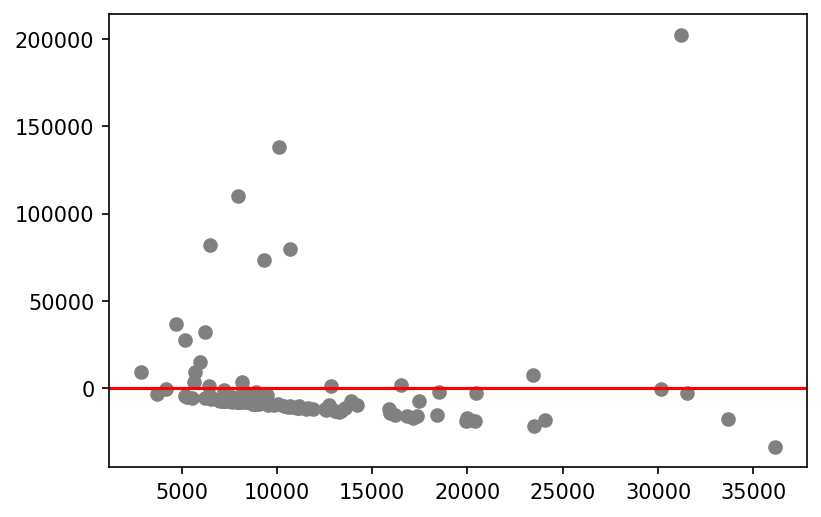

```python
import statsmodels.stats.outliers_influence as sso
st, data, ss2 = sso.summary_table(result_dropAll, alpha=0.05)

x = data[:,2]
y = data[:,8]

plt.plot(x, y, 'o', color = 'gray')
plt.axhline(y=0, color = 'red')
plt.show()
```

### 2.) Forward Selection

```python
def forward_selection(input_df, depv="y", indepv = ["x1"]):
    selected = []
    candidates = indepv.copy()

    best_adjr2 = -1
    best_subset = []

    while len(candidates) > 0:
        # print("Current Candidates: ", candidates)
        tmp_indep_subset = []
        tmp_model_adjr = []
        tmp_model_nindep = []

        for acandidate in candidates:
            tmplist = selected.copy()
            tmplist.append(acandidate)
            modelstr = depv + " ~ " + "+".join(tmplist)
            result6tmp = smf.ols(modelstr, data=input_df).fit()
            #print(df18_result6tmp.summary())
            tmp_indep_subset.append(tmplist)
            tmp_model_adjr.append(result6tmp.rsquared_adj)
            tmp_model_nindep.append(len(tmplist))

        #find the best element
        tmp_adjr2 = np.array(tmp_model_adjr)
        tmpind = tmp_adjr2.argmax()
        this_adjr2 = tmp_adjr2[tmpind]
        selected = tmp_indep_subset[tmpind]

        if this_adjr2 <= 0:
            raise("Encounterd negative Adj R2. Stop.")
        # 先註解掉省空間
        # print("===============")
        # print("Current best model: ", selected)
        # print("Current best AdjR2: ", this_adjr2)


        if this_adjr2 > best_adjr2:
            #print(" best result updated")
            best_adjr2 = this_adjr2
            best_subset = selected


        candidates = set(candidates) - set(selected)
        candidates = list(candidates)

    #print out the best result
    print("best_adjr2 = ", best_adjr2)
    print("best_subset = ", best_subset)

    #run the best model again
    modelstr = depv + " ~ " + "+".join(best_subset)
    result_dropAll= smf.ols(modelstr, data=input_df).fit()
    print(result_dropAll.summary())
```

```python
display(df_dropAll.head())
forward_selection(input_df = df_dropAll,
                  depv = 'cases',
                  indepv = ['health_exp_per_capita', 'per_capita_exp_PPP_2016', 'Physicians_per_1000_2009to18', 'Nurse_midwife_per_1000_2009to18', 'Specialist_surgical_workforce', 'HDI', 'Life_Expectancy', 'Expected_year_of_schooling', 'Mean_year_of_schooling', 'GNI_per_capita', 'Latitude', 'Density', 'Med_age', 'Urban_pop_proportion', 'BCG'])
```

|  | cases | region | health_exp_per_capita | per_capita_exp_PPP_2016 | Physicians_per_1000_2009to18 | Nurse_midwife_per_1000_2009to18 | Specialist_surgical_workforce | HDI | Life_Expectancy | Expected_year_of_schooling | Mean_year_of_schooling | GNI_per_capita | Latitude | Density | Med_age | Urban_pop_proportion | BCG |
| --- | --- | --- | --- | --- | --- | --- | --- | --- | --- | --- | --- | --- | --- | --- | --- | --- | --- |
| 0 | 6402 | Afghanistan | 57.2 | 162.8 | 0.3 | 0.3 | 0.0 | 0.498 | 64.0 | 10.4 | 3.8 | 1824.0 | 33.0000 | 60.0 | 18.0 | 0.25 | 78.0 |
| 1 | 933 | Albania | 271.5 | 759.7 | 1.2 | 3.6 | 11.6 | 0.785 | 78.5 | 14.8 | 10.0 | 11886.0 | 41.1533 | 105.0 | 36.0 | 0.63 | 99.0 |
| 2 | 6821 | Algeria | 260.4 | 998.2 | 1.8 | 2.2 | 12.1 | 0.754 | 76.3 | 14.4 | 8.0 | 13802.0 | 28.0339 | 18.0 | 29.0 | 0.73 | 99.0 |
| 6 | 7805 | Argentina | 955.2 | 1531.0 | 4.0 | 2.6 | 50.1 | 0.825 | 76.7 | 17.4 | 9.9 | 18461.0 | -38.4161 | 17.0 | 32.0 | 0.93 | 93.0 |
| 7 | 4283 | Armenia | 358.8 | 876.9 | 2.9 | 5.6 | 86.7 | 0.755 | 74.8 | 13.0 | 11.7 | 9144.0 | 40.0691 | 104.0 | 35.0 | 0.63 | 99.0 |

```
best_adjr2 =  0.14505065092821223
best_subset =  ['Urban_pop_proportion', 'Expected_year_of_schooling', 'Mean_year_of_schooling', 'Nurse_midwife_per_1000_2009to18', 'Physicians_per_1000_2009to18', 'Specialist_surgical_workforce', 'HDI', 'GNI_per_capita']
                            OLS Regression Results
==============================================================================
Dep. Variable:                  cases   R-squared:                       0.208
Model:                            OLS   Adj. R-squared:                  0.145
Method:                 Least Squares   F-statistic:                     3.290
Date:                Thu, 04 Jun 2020   Prob (F-statistic):            0.00225
Time:                        22:30:33   Log-Likelihood:                -1271.3
No. Observations:                 109   AIC:                             2561.
Df Residuals:                     100   BIC:                             2585.
Df Model:                           8
Covariance Type:            nonrobust
===================================================================================================
                                      coef    std err          t      P>|t|      [0.025      0.975]
---------------------------------------------------------------------------------------------------
Intercept                       -6.088e+04   2.21e+04     -2.759      0.007   -1.05e+05   -1.71e+04
Urban_pop_proportion             4.425e+04   1.91e+04      2.313      0.023    6287.701    8.22e+04
Expected_year_of_schooling       2364.8336   2740.371      0.863      0.390   -3071.985    7801.652
Mean_year_of_schooling          -7129.2948   2415.954     -2.951      0.004   -1.19e+04   -2336.110
Nurse_midwife_per_1000_2009to18  3156.5830   1710.710      1.845      0.068    -237.417    6550.583
Physicians_per_1000_2009to18    -9469.2867   4342.830     -2.180      0.032   -1.81e+04    -853.236
Specialist_surgical_workforce     286.2956    190.699      1.501      0.136     -92.046     664.637
HDI                               1.12e+05   7.52e+04      1.489      0.140   -3.72e+04    2.61e+05
GNI_per_capita                     -0.3412      0.317     -1.077      0.284      -0.970       0.287
==============================================================================
Omnibus:                      103.583   Durbin-Watson:                   1.974
Prob(Omnibus):                  0.000   Jarque-Bera (JB):             1038.590
Skew:                           3.274   Prob(JB):                    2.97e-226
Kurtosis:                      16.631   Cond. No.                     4.82e+05
==============================================================================

Warnings:
[1] Standard Errors assume that the covariance matrix of the errors is correctly specified.
[2] The condition number is large, 4.82e+05. This might indicate that there are
strong multicollinearity or other numerical problems.
```

adjusted R^2 = 0.145, is still low.

best_subset = ['Urban_pop_proportion', 'Expected_year_of_schooling', 'Mean_year_of_schooling', 'Nurse_midwife_per_1000_2009to18', 'Physicians_per_1000_2009to18', 'Specialist_surgical_workforce', 'HDI', 'GNI_per_capita']

```python
df_Best = df_dropAll[['cases', 'Urban_pop_proportion', 'Expected_year_of_schooling', 'Mean_year_of_schooling', 'Nurse_midwife_per_1000_2009to18', 'Physicians_per_1000_2009to18', 'Specialist_surgical_workforce', 'HDI', 'GNI_per_capita']]
result_Best = smf.ols(
    'cases ~ Urban_pop_proportion + Expected_year_of_schooling + Mean_year_of_schooling + Nurse_midwife_per_1000_2009to18 + Physicians_per_1000_2009to18 + Specialist_surgical_workforce + HDI + GNI_per_capita',
    data=df_dropAll).fit()
# Inspect the results
#print(result_Best.summary())
```

[output not shown]

### Correlation

```python
corr1 = df_Best.corr()
#corr1
```

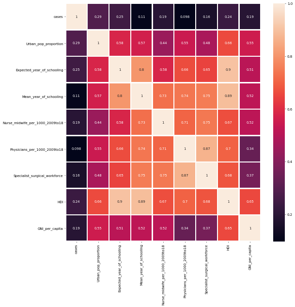

```python
import matplotlib.pyplot as plt

plt.figure(figsize=(13, 13))
_ = sns.heatmap(corr1, annot=True, linewidths=2)
```

很多variable之間的coefficient correlation都大於0.7

#### Checking Normality Assumption

To check the normality assumption, compute the residuals, plot histogram and Q-Q plot, and conduct Shapiro test.

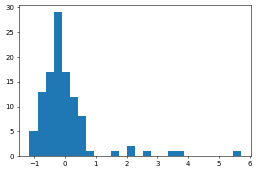

```python
_ = plt.hist(result_Best.resid_pearson, bins = 'auto')
```

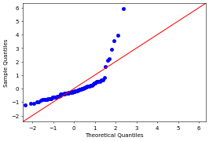

```python
fig = sm.qqplot(result_Best.resid_pearson, stats.norm, fit=True, line='45')
```

#### Shapiro Test

H0: The data is normally distributed.  
H1: The data is NOT normally distributed.

```python
stat, p = stats.shapiro(result_Best.resid_pearson)
print('Statistics=%.3f, p=%.3f' % (stat, p))
```

```
Statistics=0.671, p=0.000
```

The null hyptoehsis of Shapiro-Wilk test is that the data is normally distributed. The testing result shows that the null hyphosis can be rejected. As a result, we conclude that the normality assumption is unsatisfied.

### Studendized residual plot

```
Columns in data are: ['Obs', 'Dep Var\nPopulation', 'Predicted\nValue', 'Std Error\nMean Predict', 'Mean ci\n95% low', 'Mean ci\n95% upp', 'Predict ci\n95% low', 'Predict ci\n95% upp', 'Residual', 'Std Error\nResidual', 'Student\nResidual', "Cook's\nD"]
```

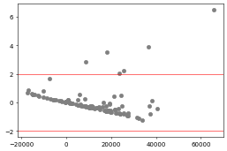

```python
st, data, ss2 = sso.summary_table(result_Best, alpha=0.05)
print("Columns in data are: %s" % ss2)

#Predicted value
x = data[:, 2]
#Studentized Residual
y = data[:, 10]

plt.plot(x, y, 'o', color = 'gray')
plt.axhline(y=2, color = 'red', lw = 0.8)
plt.axhline(y=-2, color = 'red', lw = 0.8)
plt.show()
```

about 6 outliers.

## 3.) Normality

以下嘗試：

```
a. 變數標準化
b. y取log
c. y開根號
d. y取倒數(reciprocal)
```

### 3.a.) Using Standardized Values

```python
#把前面forward選出來的best column挑出來
dep_var = df_dropAll['cases']
indep_var = df_dropAll[['Urban_pop_proportion', 'Expected_year_of_schooling', 'Mean_year_of_schooling', 'Nurse_midwife_per_1000_2009to18', 'Physicians_per_1000_2009to18', 'Specialist_surgical_workforce', 'HDI', 'GNI_per_capita']]
#Change the names so that we will not get confused
indep_var.columns = ['Urban_pop_proportion_std', 'Expected_year_of_schooling_std', 'Mean_year_of_schooling_std', 'Nurse_midwife_per_1000_2009to18_std', 'Physicians_per_1000_2009to18_std', 'Specialist_surgical_workforce_std', 'HDI_std', 'GNI_per_capita_std']
```

```python
dep_var = df_dropAll['cases']
indep_var = df_dropAll[['health_exp_per_capita', 'per_capita_exp_PPP_2016', 'Physicians_per_1000_2009to18', 'Nurse_midwife_per_1000_2009to18', 'Specialist_surgical_workforce', 'HDI', 'Life_Expectancy', 'Expected_year_of_schooling', 'Mean_year_of_schooling', 'GNI_per_capita', 'Latitude', 'Density', 'Med_age', 'Urban_pop_proportion', 'BCG']]
indep_var.columns = ['health_exp_per_capita_std', 'per_capita_exp_PPP_2016_std', 'Physicians_per_1000_2009to18_std', 'Nurse_midwife_per_1000_2009to18_std', 'Specialist_surgical_workforce_std', 'HDI_std', 'Life_Expectancy_std', 'Expected_year_of_schooling_std', 'Mean_year_of_schooling_std', 'GNI_per_capita_std', 'Latitude_std', 'Density_std', 'Med_age_std', 'Urban_pop_proportion_std', 'BCG_std']
```

```python
indep_mean = indep_var.mean()
indep_std = indep_var.std()
print("indep_mean = \n", indep_mean)
print("indep_std = \n", indep_std)
```

```
indep_mean =
 health_exp_per_capita_std                402.185321
per_capita_exp_PPP_2016_std              789.558716
Physicians_per_1000_2009to18_std           1.349541
Nurse_midwife_per_1000_2009to18_std        2.833945
Specialist_surgical_workforce_std         26.193578
HDI_std                                    0.663183
Life_Expectancy_std                       69.945872
Expected_year_of_schooling_std            12.548624
Mean_year_of_schooling_std                 7.741284
GNI_per_capita_std                     11364.899083
Latitude_std                              14.812738
Density_std                              136.018349
Med_age_std                               28.128440
Urban_pop_proportion_std                   0.539541
BCG_std                                   91.137615
dtype: float64
indep_std =
 health_exp_per_capita_std                726.263148
per_capita_exp_PPP_2016_std              905.188843
Physicians_per_1000_2009to18_std           1.458286
Nurse_midwife_per_1000_2009to18_std        2.856157
Specialist_surgical_workforce_std         33.150008
HDI_std                                    0.140733
Life_Expectancy_std                        7.314427
Expected_year_of_schooling_std             2.512694
Mean_year_of_schooling_std                 3.054633
GNI_per_capita_std                     13730.152964
Latitude_std                              23.801300
Density_std                              228.708126
Med_age_std                                8.439437
Urban_pop_proportion_std                   0.209476
BCG_std                                   10.958227
dtype: float64
```

```python
indep_var = (indep_var - indep_mean) / indep_std
```

```python
indep_var.head()
```

|  | health_exp_per_capita_std | per_capita_exp_PPP_2016_std | Physicians_per_1000_2009to18_std | Nurse_midwife_per_1000_2009to18_std | Specialist_surgical_workforce_std | HDI_std | Life_Expectancy_std | Expected_year_of_schooling_std | Mean_year_of_schooling_std | GNI_per_capita_std | Latitude_std | Density_std | Med_age_std | Urban_pop_proportion_std | BCG_std |
| --- | --- | --- | --- | --- | --- | --- | --- | --- | --- | --- | --- | --- | --- | --- | --- |
| 0 | -0.475014 | -0.692407 | -0.719709 | -0.887187 | -0.790153 | -1.173740 | -0.812896 | -0.855108 | -1.290265 | -0.694887 | 0.764129 | -0.332381 | -1.200132 | -1.382215 | -1.198881 |
| 1 | -0.179942 | -0.032986 | -0.102546 | 0.268212 | -0.440228 | 0.865588 | 1.169487 | 0.896001 | 0.739439 | 0.037953 | 1.106686 | -0.135624 | 0.932712 | 0.431833 | 0.717487 |
| 2 | -0.195226 | 0.230495 | 0.308896 | -0.221957 | -0.425146 | 0.645312 | 0.868712 | 0.736809 | 0.084696 | 0.177500 | 0.555481 | -0.516022 | 0.103272 | 0.909213 | 0.717487 |
| 6 | 0.761452 | 0.819101 | 1.817517 | -0.081909 | 0.721159 | 1.149815 | 0.923398 | 1.930747 | 0.706702 | 0.516826 | -2.236384 | -0.520394 | 0.458746 | 1.863975 | 0.169953 |
| 7 | -0.059738 | 0.096490 | 1.063206 | 0.968453 | 1.825231 | 0.652418 | 0.663638 | 0.179638 | 1.295971 | -0.161753 | 1.061134 | -0.139997 | 0.814220 | 0.431833 | 0.717487 |

```python
print(indep_var.mean())
print(indep_var.std())
```

```
health_exp_per_capita_std              9.778111e-17
per_capita_exp_PPP_2016_std            1.894509e-16
Physicians_per_1000_2009to18_std       8.963268e-17
Nurse_midwife_per_1000_2009to18_std    7.741005e-17
Specialist_surgical_workforce_std     -1.018553e-18
HDI_std                                1.104112e-15
Life_Expectancy_std                    1.087815e-15
Expected_year_of_schooling_std         2.098220e-16
Mean_year_of_schooling_std            -2.169518e-16
GNI_per_capita_std                     3.055660e-18
Latitude_std                           2.444528e-17
Density_std                            4.074213e-17
Med_age_std                           -2.393600e-17
Urban_pop_proportion_std              -1.295600e-15
BCG_std                               -1.120409e-16
dtype: float64
health_exp_per_capita_std              1.0
per_capita_exp_PPP_2016_std            1.0
Physicians_per_1000_2009to18_std       1.0
Nurse_midwife_per_1000_2009to18_std    1.0
Specialist_surgical_workforce_std      1.0
HDI_std                                1.0
Life_Expectancy_std                    1.0
Expected_year_of_schooling_std         1.0
Mean_year_of_schooling_std             1.0
GNI_per_capita_std                     1.0
Latitude_std                           1.0
Density_std                            1.0
Med_age_std                            1.0
Urban_pop_proportion_std               1.0
BCG_std                                1.0
dtype: float64
```

#### Create a new dataset with standardized and augmented data

```python
df_stdBest = indep_var.copy()
df_stdBest.insert(0, 'cases', dep_var)
```

```python
df_stdBest.head()
```

|  | cases | health_exp_per_capita_std | per_capita_exp_PPP_2016_std | Physicians_per_1000_2009to18_std | Nurse_midwife_per_1000_2009to18_std | Specialist_surgical_workforce_std | HDI_std | Life_Expectancy_std | Expected_year_of_schooling_std | Mean_year_of_schooling_std | GNI_per_capita_std | Latitude_std | Density_std | Med_age_std | Urban_pop_proportion_std | BCG_std |
| --- | --- | --- | --- | --- | --- | --- | --- | --- | --- | --- | --- | --- | --- | --- | --- | --- |
| 0 | 6402 | -0.475014 | -0.692407 | -0.719709 | -0.887187 | -0.790153 | -1.173740 | -0.812896 | -0.855108 | -1.290265 | -0.694887 | 0.764129 | -0.332381 | -1.200132 | -1.382215 | -1.198881 |
| 1 | 933 | -0.179942 | -0.032986 | -0.102546 | 0.268212 | -0.440228 | 0.865588 | 1.169487 | 0.896001 | 0.739439 | 0.037953 | 1.106686 | -0.135624 | 0.932712 | 0.431833 | 0.717487 |
| 2 | 6821 | -0.195226 | 0.230495 | 0.308896 | -0.221957 | -0.425146 | 0.645312 | 0.868712 | 0.736809 | 0.084696 | 0.177500 | 0.555481 | -0.516022 | 0.103272 | 0.909213 | 0.717487 |
| 6 | 7805 | 0.761452 | 0.819101 | 1.817517 | -0.081909 | 0.721159 | 1.149815 | 0.923398 | 1.930747 | 0.706702 | 0.516826 | -2.236384 | -0.520394 | 0.458746 | 1.863975 | 0.169953 |
| 7 | 4283 | -0.059738 | 0.096490 | 1.063206 | 0.968453 | 1.825231 | 0.652418 | 0.663638 | 0.179638 | 1.295971 | -0.161753 | 1.061134 | -0.139997 | 0.814220 | 0.431833 | 0.717487 |

#### Correlation Coefficients

```python
corr2c = df_stdBest.corr()
corr2c
```

|  | cases | health_exp_per_capita_std | per_capita_exp_PPP_2016_std | Physicians_per_1000_2009to18_std | Nurse_midwife_per_1000_2009to18_std | Specialist_surgical_workforce_std | HDI_std | Life_Expectancy_std | Expected_year_of_schooling_std | Mean_year_of_schooling_std | GNI_per_capita_std | Latitude_std | Density_std | Med_age_std | Urban_pop_proportion_std | BCG_std |
| --- | --- | --- | --- | --- | --- | --- | --- | --- | --- | --- | --- | --- | --- | --- | --- | --- |
| cases | 1.000000 | 0.156221 | 0.214419 | 0.097689 | 0.194377 | 0.159102 | 0.236201 | 0.235727 | 0.247937 | 0.105088 | 0.190418 | 0.024410 | -0.003988 | 0.187648 | 0.290337 | -0.005024 |
| health_exp_per_capita_std | 0.156221 | 1.000000 | 0.906263 | 0.480763 | 0.570395 | 0.431534 | 0.555642 | 0.516632 | 0.486021 | 0.461336 | 0.630319 | 0.219648 | 0.041616 | 0.531677 | 0.486356 | -0.253597 |
| per_capita_exp_PPP_2016_std | 0.214419 | 0.906263 | 1.000000 | 0.605834 | 0.673305 | 0.554718 | 0.735753 | 0.656072 | 0.625037 | 0.623743 | 0.807820 | 0.280194 | 0.010667 | 0.691718 | 0.635484 | -0.040080 |
| Physicians_per_1000_2009to18_std | 0.097689 | 0.480763 | 0.605834 | 1.000000 | 0.706148 | 0.866858 | 0.700796 | 0.608778 | 0.663819 | 0.741624 | 0.336781 | 0.445446 | -0.120637 | 0.748518 | 0.545974 | 0.091697 |
| Nurse_midwife_per_1000_2009to18_std | 0.194377 | 0.570395 | 0.673305 | 0.706148 | 1.000000 | 0.745133 | 0.667178 | 0.529703 | 0.582251 | 0.726898 | 0.516329 | 0.550442 | -0.052729 | 0.703701 | 0.443940 | 0.096056 |
| Specialist_surgical_workforce_std | 0.159102 | 0.431534 | 0.554718 | 0.866858 | 0.745133 | 1.000000 | 0.677260 | 0.549572 | 0.645257 | 0.751910 | 0.371127 | 0.531005 | -0.171922 | 0.755396 | 0.477260 | 0.078962 |
| HDI_std | 0.236201 | 0.555642 | 0.735753 | 0.700796 | 0.667178 | 0.677260 | 1.000000 | 0.883341 | 0.903699 | 0.893086 | 0.654893 | 0.356411 | -0.013357 | 0.871168 | 0.661192 | 0.271983 |
| Life_Expectancy_std | 0.235727 | 0.516632 | 0.656072 | 0.608778 | 0.529703 | 0.549572 | 0.883341 | 1.000000 | 0.762668 | 0.694534 | 0.542716 | 0.374321 | 0.103698 | 0.796853 | 0.564290 | 0.298492 |
| Expected_year_of_schooling_std | 0.247937 | 0.486021 | 0.625037 | 0.663819 | 0.582251 | 0.645257 | 0.903699 | 0.762668 | 1.000000 | 0.803945 | 0.512643 | 0.238387 | -0.032464 | 0.782772 | 0.582320 | 0.231752 |
| Mean_year_of_schooling_std | 0.105088 | 0.461336 | 0.623743 | 0.741624 | 0.726898 | 0.751910 | 0.893086 | 0.694534 | 0.803945 | 1.000000 | 0.518238 | 0.381896 | -0.106097 | 0.800389 | 0.565998 | 0.231522 |
| GNI_per_capita_std | 0.190418 | 0.630319 | 0.807820 | 0.336781 | 0.516329 | 0.371127 | 0.654893 | 0.542716 | 0.512643 | 0.518238 | 1.000000 | 0.266522 | 0.007907 | 0.543005 | 0.553227 | 0.084815 |
| Latitude_std | 0.024410 | 0.219648 | 0.280194 | 0.445446 | 0.550442 | 0.531005 | 0.356411 | 0.374321 | 0.238387 | 0.381896 | 0.266522 | 1.000000 | -0.028084 | 0.501246 | 0.164256 | 0.036912 |
| Density_std | -0.003988 | 0.041616 | 0.010667 | -0.120637 | -0.052729 | -0.171922 | -0.013357 | 0.103698 | -0.032464 | -0.106097 | 0.007907 | -0.028084 | 1.000000 | 0.021111 | -0.224065 | 0.113209 |
| Med_age_std | 0.187648 | 0.531677 | 0.691718 | 0.748518 | 0.703701 | 0.755396 | 0.871168 | 0.796853 | 0.782772 | 0.800389 | 0.543005 | 0.501246 | 0.021111 | 1.000000 | 0.544843 | 0.259419 |
| Urban_pop_proportion_std | 0.290337 | 0.486356 | 0.635484 | 0.545974 | 0.443940 | 0.477260 | 0.661192 | 0.564290 | 0.582320 | 0.565998 | 0.553227 | 0.164256 | -0.224065 | 0.544843 | 1.000000 | 0.077434 |
| BCG_std | -0.005024 | -0.253597 | -0.040080 | 0.091697 | 0.096056 | 0.078962 | 0.271983 | 0.298492 | 0.231752 | 0.231522 | 0.084815 | 0.036912 | 0.113209 | 0.259419 | 0.077434 | 1.000000 |

```python
forward_selection(input_df = df_stdBest,
                  depv = 'cases',
                  indepv = ['health_exp_per_capita_std', 'per_capita_exp_PPP_2016_std', 'Physicians_per_1000_2009to18_std', 'Nurse_midwife_per_1000_2009to18_std', 'Specialist_surgical_workforce_std', 'HDI_std', 'Life_Expectancy_std', 'Expected_year_of_schooling_std', 'Mean_year_of_schooling_std', 'GNI_per_capita_std', 'Latitude_std', 'Density_std', 'Med_age_std', 'Urban_pop_proportion_std', 'BCG_std'])
```

```
best_adjr2 =  0.14505065092821223
best_subset =  ['Urban_pop_proportion_std', 'Expected_year_of_schooling_std', 'Mean_year_of_schooling_std', 'Nurse_midwife_per_1000_2009to18_std', 'Physicians_per_1000_2009to18_std', 'Specialist_surgical_workforce_std', 'HDI_std', 'GNI_per_capita_std']
                            OLS Regression Results
==============================================================================
Dep. Variable:                  cases   R-squared:                       0.208
Model:                            OLS   Adj. R-squared:                  0.145
Method:                 Least Squares   F-statistic:                     3.290
Date:                Sun, 07 Jun 2020   Prob (F-statistic):            0.00225
Time:                        10:55:31   Log-Likelihood:                -1271.3
No. Observations:                 109   AIC:                             2561.
Df Residuals:                     100   BIC:                             2585.
Df Model:                           8
Covariance Type:            nonrobust
=======================================================================================================
                                          coef    std err          t      P>|t|      [0.025      0.975]
-------------------------------------------------------------------------------------------------------
Intercept                            1.151e+04   2813.078      4.093      0.000    5932.135    1.71e+04
Urban_pop_proportion_std             9269.7449   4008.435      2.313      0.023    1317.125    1.72e+04
Expected_year_of_schooling_std       5942.1038   6885.715      0.863      0.390   -7718.958    1.96e+04
Mean_year_of_schooling_std          -2.178e+04   7379.853     -2.951      0.004   -3.64e+04   -7135.958
Nurse_midwife_per_1000_2009to18_std  9015.6970   4886.056      1.845      0.068    -678.099    1.87e+04
Physicians_per_1000_2009to18_std    -1.381e+04   6333.087     -2.180      0.032   -2.64e+04   -1244.261
Specialist_surgical_workforce_std    9490.7009   6321.680      1.501      0.136   -3051.332     2.2e+04
HDI_std                              1.576e+04   1.06e+04      1.489      0.140   -5231.103    3.67e+04
GNI_per_capita_std                  -4685.1023   4350.790     -1.077      0.284   -1.33e+04    3946.742
==============================================================================
Omnibus:                      103.583   Durbin-Watson:                   1.974
Prob(Omnibus):                  0.000   Jarque-Bera (JB):             1038.590
Skew:                           3.274   Prob(JB):                    2.97e-226
Kurtosis:                      16.631   Cond. No.                         10.6
==============================================================================

Warnings:
[1] Standard Errors assume that the covariance matrix of the errors is correctly specified.
```

adjusted r^2 不變

```python
result_stdBest = smf.ols(
    'cases ~ Urban_pop_proportion_std + Expected_year_of_schooling_std + Mean_year_of_schooling_std + Nurse_midwife_per_1000_2009to18_std + Physicians_per_1000_2009to18_std + Specialist_surgical_workforce_std + HDI_std + GNI_per_capita_std',
    data=df_stdBest).fit()
# Inspect the results
#print(result_stdBest.summary())
```

```
Columns in data are: ['Obs', 'Dep Var\nPopulation', 'Predicted\nValue', 'Std Error\nMean Predict', 'Mean ci\n95% low', 'Mean ci\n95% upp', 'Predict ci\n95% low', 'Predict ci\n95% upp', 'Residual', 'Std Error\nResidual', 'Student\nResidual', "Cook's\nD"]
```

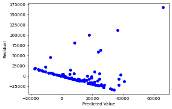

```python
st, data, ss2 = sso.summary_table(result_stdBest, alpha=0.05)
print("Columns in data are: %s" % ss2)
#Predicted value
x = data[:, 2]
#Residual
y = data[:, 8]
_ = plt.plot(x, y, 'o', color = 'b')
plt.xlabel('Predicted Value')
plt.ylabel('Residual')
plt.show()
```

#### Checking residual normality

To check the normality assumption, compute the residuals, plot histogram and Q-Q plot, and conduct Shapiro test.

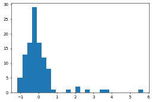

```python
_ = plt.hist(result_stdBest.resid_pearson, bins = 'auto')
```

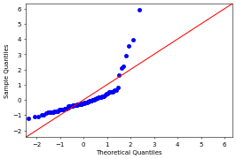

```python
fig = sm.qqplot(result_stdBest.resid_pearson, stats.norm, fit=True, line='45')
```

```python
stat, p = stats.shapiro(result_stdBest.resid_pearson)
print('Statistics=%.3f, p=%.3f' % (stat, p))
```

```
Statistics=0.671, p=0.000
```

還是不normal